# Extended Example Machine Readable Hypothesis

```r
library(scienceverse)
library(dplyr)
```

```r
library(tidyr)
library(ggplot2)
```

The demo below extends the example from:

Lakens, D., & DeBruine, L. M. (2020, January 27). Improving Transparency, Falsifiability, and Rigour by Making Hypothesis Tests Machine Readable. https://doi.org/10.31234/osf.io/5xcda

## Set up the study

Set up the study with a name and any additional info you want to add.

```r
study <- study(name = "Kinship and Prosocial Behaviour",
               abstract = "A reanalysis of data from DeBruine (2002) Facial Resemblance Enhances Trust, PRSLB.")
```

## Authors

Add each author in the following format. Use the function `credit_roles()` to see a list of the roles and their descriptions. Use `credit_roles("name")` or `credit_roles("abbr")` to just see their names or abbreviations. You can also add any further info, like an orcid or email address.

```r
study <- add_author(study,
                    orcid = "0000-0002-7523-5539",
                    surname = "DeBruine",
                    given = "Lisa M.",
                    roles = c("con", "dat", "sof", "dra", "edi"),
                    email = "lisa.debruine@glasgow.ac.uk") %>%
         add_author(orcid = "0000-0002-0247-239X",
                    surname = "Lakens",
                    given = "Daniël",
                    roles = c("con", "ana", "dra", "edi"))
```

## Hypotheses

Now add a hypothesis with a verbal description. You can add more than one hypothesis, but this demo study only has one.

```r
study <- add_hypothesis(study, id = "self_pref",
                        description = "Cues of kinship will increase prosocial behaviour. Cues of kinship will be manipulated by morphed facial self-resemblance. Prosocial behaviour will be measured by responses in the trust game. The prediction is that the number of trusting AND/OR reciprocating moves will be greater to self morphs than to other morphs.")
```

## Analyses

Add all relevant analyses for testing this hypothesis in the order that they should be run. Do any data prep first. Each analysis needs an `id` for reference in the criteria later. The `code` can be R code (wrap it in {} if you need more than one line) or the file path for a .R file. You can also add other information about your analysis, such as the software it’s running on.

```r
study <- add_analysis(study, id = "trust",
                      code = t.test(kin$trust_self,
                                    kin$trust_other,
                                    paired = TRUE,
                                    conf.level = 0.975),
                      software = R.version.string) %>%
         add_analysis(id = "recip",
                      code = t.test(kin$recip_self,
                                    kin$recip_other,
                                    paired = TRUE,
                                    conf.level = 0.975),
                      software = R.version.string)
```

### Auxillary Assumptions

You can also test auxillary assumptions and set up more complicated decision rules for evaluation. Here, we’ll test whether the resulting data are normally distributed and use an alternative statistical test if they are not. Therefore, we need to add analyses to do the normality tests and analyses to do the non-parametric versions.

```r
# test normality of the 4 dvs
study <- add_analysis(study, id = "norm",
  code = {
    ts <- shapiro.test(kin$trust_self)$p.value
    to <- shapiro.test(kin$trust_other)$p.value
    rs <- shapiro.test(kin$recip_self)$p.value
    ro <- shapiro.test(kin$recip_other)$p.value
  },
  return = c("ts", "to", "rs", "ro"),
  software = R.version.string)

study <- add_analysis(study,
                      id = "trust_wilcox",
                      code = wilcox.test(kin$trust_self,
                                    kin$trust_other,
                                    paired = TRUE,
                                    conf.level = 0.975,
                                    conf.int = TRUE),
                      software = R.version.string) %>%
         add_analysis(id = "recip_wilcox",
                      code = wilcox.test(kin$recip_self,
                                    kin$recip_other,
                                    paired = TRUE,
                                    conf.level = 0.975,
                                    conf.int = TRUE),
                      software = R.version.string)
```

N.B. It is up to you how much you want to break your analysis into separate analyses in scienceverse. At one extreme, you could include all of your analyses in a single .R file that returns a list of all relevant values, instead of separating them into different analyses. However, smaller logical groupings of analyses make it easier for readers to find and understand the code relevant to a result.

## Criteria

Next, add the criteria you will need to check to corroborate or falsify each hypothesis. Each criterion needs a unique `id` so you can reference it next in the evaluation. Then, optionally specify the `hypothesis_id` and `analysis_id` where you’ll look for the result. If you omit these it will default to the last one added. For example, the analysis `trust` returns a list from the function `t.test`, which includes a value for `conf.int`. To see if the first number in this vector is larger than 0, set `result` to “conf.int[1]”, `operator` to “>” , and `comparator` to $0$. The options for `operator` are “>”, “<”, “=”, and “!=”.

```r
study <- study %>%
  add_criterion(id = "t_lo",
                result = "conf.int[1]",
                operator = ">",
                comparator = 0,
                hypothesis_id = "self_pref",
                analysis_id = "trust") %>%
  add_criterion("t_hi",    "conf.int[2]", ">", 0.2, "trust") %>%
  add_criterion("r_lo",    "conf.int[1]", ">", 0.0, "recip") %>%
  add_criterion("r_hi",    "conf.int[2]", ">", 0.2, "recip") %>%
  add_criterion("ts_norm", "ts",          ">", 0.05, "norm") %>%
  add_criterion("to_norm", "to",          ">", 0.05, "norm") %>%
  add_criterion("rs_norm", "rs",          ">", 0.05, "norm") %>%
  add_criterion("ro_norm", "ro",          ">", 0.05, "norm")%>%
  add_criterion("t_lo_w",  "conf.int[1]", ">", 0.0, "trust_wilcox") %>%
  add_criterion("t_hi_w",  "conf.int[2]", ">", 0.2, "trust_wilcox") %>%
  add_criterion("r_lo_w",  "conf.int[1]", ">", 0.0, "recip_wilcox") %>%
  add_criterion("r_hi_w",  "conf.int[2]", ">", 0.2, "recip_wilcox")
```

## Evaluation

Add evaluation criteria for corroboration and falsification. The logical `evaluation` should reference the criterion `id`s above and can consist of those ids and the symbols `(`, `)`, `&`, and `|`. You can optionally include a verbal `description` of the criterion to clarify the logical evaluation.

```r
study <- add_eval(study, "corroboration",
                  "(ts_norm & to_norm & t_lo & t_hi) |
                   (!(ts_norm & to_norm) & t_lo_w & t_hi_w) |
                   (rs_norm & ro_norm & r_lo & r_hi) |
                   (!(rs_norm & ro_norm) & r_lo_w & r_hi_w)",
                  description = "The hypothesis is corroborated if the 97.5% CI lower bound is greater than 0 and the 97.5% CI upper bound is greater than 0.2 (the SESOI) for either the trust or reciprocation moves. Use t.test if the data are normally distributed, or Wilcox test otherwise.")

study <- add_eval(study, "falsification",
                  "( (ts_norm & to_norm & !t_hi) |
                     (!(ts_norm & to_norm) & !t_hi_w) ) &
                   ( (rs_norm & ro_norm & !r_hi) |
                     (!(rs_norm & ro_norm) & !r_hi_w) )",
                  description = "The hypothesis is falsified if the 97.5% CI upper bound is smaller than 0.2 (the SESOI) for both trust and reciprocation. Use t.test if the data are normally distributed, or Wilcox test otherwise.")
```

## Saving

At this point, you can save your study to a machine-readable JSON-formatted file.

```r
study_save(study, "ext_prereg.json", format = "json")
```

```
#> Saving to /Users/lisad/rproj/scienceverse/machine-readable/example/extended/ext_prereg.json
```

You can also export a human-readable pre-registration using the built-in “prereg” template.

```r
study_save(study, "ext_prereg.html", format = "prereg")
```

```
#> Saving to /Users/lisad/rproj/scienceverse/machine-readable/example/extended/ext_prereg.html
```

## Power Analysis

If your data have a factorial design, you can add simulated data by describing the design parameters as for the `faux::sim_design` function.

```r
study <- add_sim_data(study, data_id = "kin",
                      within = list(game = c("trust", "recip"),
                                    person = c("self", "other")),
                      n = 24,
                      mu = list(trust_self  = 1.2,
                                trust_other = 0.8,
                                recip_self  = 1.8,
                                recip_other = 1.8),
                      sd = 0.8, r = 0.5)
```

```
#> id set to dataType string
```

```
#> trust_self set to dataType float
```

```
#> trust_other set to dataType float
```

```
#> recip_self set to dataType float
```

```
#> recip_other set to dataType float
```

The `study_power` function runs the specified number of replications: simulating your data, running the analyses, and evaluating the criteria to produce a summary of the proportion of simulation where each hypothesis was corroborated, falsified, or inconclusive.

```r
study <- study_power(study, rep = 100)
```

```
#> Hypothesis self_pref
#>       corroboration: 45.0%
#>       falsification: 0.0%
#>       inconclusive:  55.0%
```

You can access the values for each criterion for each simulation with the function `get_power` (set `values = TRUE`). This returns a list of hypotheses and their associated criteria that you can then plot or further assess.

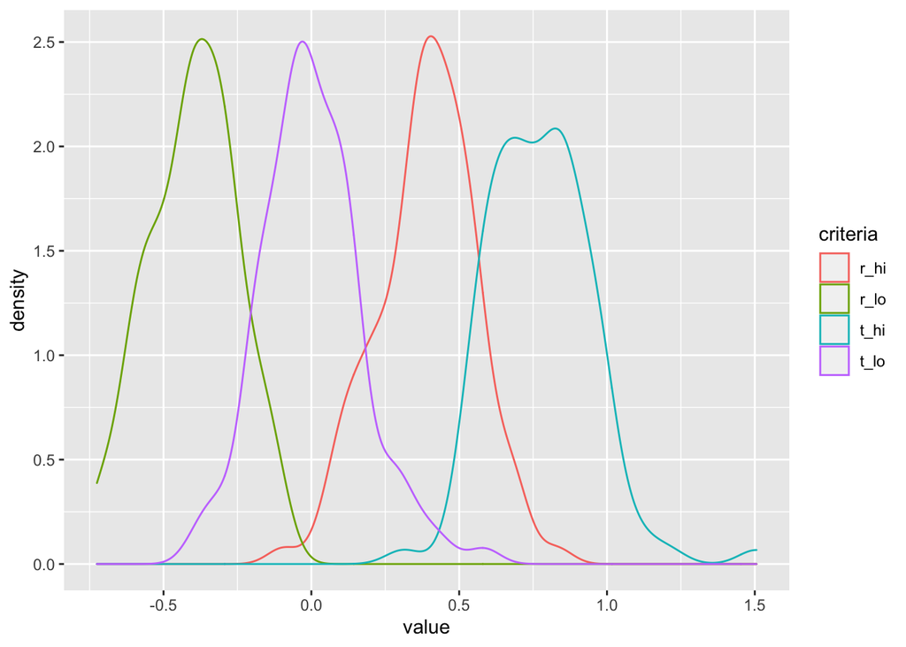

Criteria values for 100 simulated studies

```r
power <- get_power(study, values = TRUE)

as_tibble(power$self_pref$criteria) %>%
  pivot_longer(t_lo:r_hi,
               names_to = "criteria",
               values_to = "value") %>%
  ggplot(aes(value, color = criteria)) +
  geom_density()
```

## Data

The `id` you give the data can be used in the analysis code to refer to this dataset. The `data` argument can be a data frame or a file path to a data file or a PsychDS-formatted codebook. You can optionally add column parameters such as descriptions with the argument `vardesc` and other dataset parameters as additional arguments.

```r
kin_data <- data.frame(
  trust_self  = c(1,2,2,1,1,1,1,1,2,0,2,0,1,2,2,3,2,2,1,1,2,0,0,1),
  trust_other = c(1,2,2,0,1,0,0,0,1,0,1,0,1,1,1,0,1,2,2,0,0,0,2,1),
  recip_self  = c(0,1,3,2,1,1,1,3,3,2,3,1,1,2,3,3,3,1,1,1,3,0,3,1),
  recip_other = c(1,1,2,2,3,2,1,3,3,1,3,0,1,3,3,3,3,0,3,0,1,0,3,2)
)

desc <- list(
  description = list(
    trust_self  = "Number of trusting moves towards self-morphs",
    trust_other = "Number of trusting moves towards self-morphs",
    recip_self  = "Number of reciprocating moves towards other-morphs",
    recip_other = "Number of reciprocating moves towards other-morphs"
  ),
  dataType = rep("int", 4) # all variables are integer types
)

study <- add_data(study, id = "kin",
                  data = kin_data,
                  vardesc = desc,
                  url = "https://osf.io/ewfhs/")
```

## Run Analyses

When you run `study_analyse`, the data are loaded as their `id` names and the analyses are run in order. For example, the data from the section above will be available to your analyses as a dataframe called `kin`. The analysis is run in a separate environment, so you won’t see any new objects in the global environment. Therefore, changes you make to, e.g., a dataframe called `kin` in your global environment won’t affect the analysis. The evaluation of each criterion and hypothesis is printed as a message.

```r
study <- study_analyse(study)
```

```
#> Hypothesis self_pref: Cues of kinship will increase prosocial behaviour. Cues of kinship will be manipulated by morphed facial self-resemblance. Prosocial behaviour will be measured by responses in the trust game. The prediction is that the number of trusting AND/OR reciprocating moves will be gr…
#>
#> Criterion t_lo:
#> * conf.int[1] > 0 is TRUE
#> * conf.int[1] = 0.021
#>
#> Criterion t_hi:
#> * conf.int[2] > 0.2 is TRUE
#> * conf.int[2] = 0.979
#>
#> Criterion r_lo:
#> * conf.int[1] > 0 is FALSE
#> * conf.int[1] = -0.509
#>
#> Criterion r_hi:
#> * conf.int[2] > 0.2 is TRUE
#> * conf.int[2] = 0.426
#>
#> Criterion ts_norm:
#> * ts > 0.05 is FALSE
#> * ts = 0.004
#>
#> Criterion to_norm:
#> * to > 0.05 is FALSE
#> * to = 0.000
#>
#> Criterion rs_norm:
#> * rs > 0.05 is FALSE
#> * rs = 0.000
#>
#> Criterion ro_norm:
#> * ro > 0.05 is FALSE
#> * ro = 0.001
#>
#> Criterion t_lo_w:
#> * conf.int[1] > 0 is FALSE
#> * conf.int[1] = -0.000
#>
#> Criterion t_hi_w:
#> * conf.int[2] > 0.2 is TRUE
#> * conf.int[2] = 1.500
#>
#> Criterion r_lo_w:
#> * conf.int[1] > 0 is FALSE
#> * conf.int[1] = -1.500
#>
#> Criterion r_hi_w:
#> * conf.int[2] > 0.2 is TRUE
#> * conf.int[2] = 1.000
#>
#> Conclusion: inconclusive
#> * Corroborate ((ts_norm & to_norm & t_lo & t_hi) |
#>                    (!(ts_norm & to_norm) & t_lo_w & t_hi_w) |
#>                    (rs_norm & ro_norm & r_lo & r_hi) |
#>                    (!(rs_norm & ro_norm) & r_lo_w & r_hi_w)): FALSE
#> * Falsify (( (ts_norm & to_norm & !t_hi) |
#>                      (!(ts_norm & to_norm) & !t_hi_w) ) &
#>                    ( (rs_norm & ro_norm & !r_hi) |
#>                      (!(rs_norm & ro_norm) & !r_hi_w) )): FALSE
```

## Save and reload

At this point, you can save the post-registration version of your study to a JSON-formatted file and also export a human-readable post-registration report.

```r
study_save(study, "ext_postreg.json", "json")
```

```
#> Saving to /Users/lisad/rproj/scienceverse/machine-readable/example/extended/ext_postreg.json
```

```r
study_save(study, "ext_postreg.html", "postreg")
```

```
#> Saving to /Users/lisad/rproj/scienceverse/machine-readable/example/extended/ext_postreg.html
```

You can reload and edit your study by loading the .json file with the study() function.

```r
study2 <- study("ext_postreg.json")

study2 # displays a summary
```

```
#> Kinship and Prosocial Behaviour
#> -------------------------------
#>
#> * Hypotheses: self_pref
#> * Data: kin
#> * Analyses: trust, recip, norm, trust_wilcox, recip_wilcox
#>
#> Hypothesis self_pref: Cues of kinship will increase prosocial behaviour. Cues of kinship will be manipulated by morphed facial self-resemblance. Prosocial behaviour will be measured by responses in the trust game. The prediction is that the number of trusting AND/OR reciprocating moves will be gr…
#>
#> Criterion t_lo:
#> * conf.int[1] > 0 is TRUE
#> * conf.int[1] = 0.021
#>
#> Criterion t_hi:
#> * conf.int[2] > 0.2 is TRUE
#> * conf.int[2] = 0.979
#>
#> Criterion r_lo:
#> * conf.int[1] > 0 is FALSE
#> * conf.int[1] = -0.509
#>
#> Criterion r_hi:
#> * conf.int[2] > 0.2 is TRUE
#> * conf.int[2] = 0.426
#>
#> Criterion ts_norm:
#> * ts > 0.05 is FALSE
#> * ts = 0.004
#>
#> Criterion to_norm:
#> * to > 0.05 is FALSE
#> * to = 0.000
#>
#> Criterion rs_norm:
#> * rs > 0.05 is FALSE
#> * rs = 0.000
#>
#> Criterion ro_norm:
#> * ro > 0.05 is FALSE
#> * ro = 0.001
```

[output cut: 11 more lines]

```
#> * conf.int[1] = -1.500
#>
#> Criterion r_hi_w:
#> * conf.int[2] > 0.2 is TRUE
#> * conf.int[2] = 1.000
#>
#> Conclusion: inconclusive
#> * Corroborate ((ts_norm & to_norm & t_lo & t_hi) |
#>                    (!(ts_norm & to_norm) & t_lo_w & t_hi_w) |
#>                    (rs_norm & ro_norm & r_lo & r_hi) |
#>                    (!(rs_norm & ro_norm) & r_lo_w & r_hi_w)): FALSE
#> * Falsify (( (ts_norm & to_norm & !t_hi) |
#>                      (!(ts_norm & to_norm) & !t_hi_w) ) &
#>                    ( (rs_norm & ro_norm & !r_hi) |
#>                      (!(rs_norm & ro_norm) & !r_hi_w) )): FALSE
```

## Edit analyses

If you want to explore how the results change if you change criteria or analyses, you can use the functions `update_analysis` or `update_criteria`.

For example, we can change the analyses to use 95% CIs instead of 97.5% CIs. Make sure to re-analyse after changing data, analyses or criteria (this doesn’t happen automatically because some analyses can take a very long time).

```r
study2 <- study2 %>%
  update_analysis(id = "trust",
                  code = t.test(kin$trust_self,
                                kin$trust_other,
                                paired = TRUE,
                                conf.level = 0.95)) %>%
  update_analysis(id = "recip",
                  code = t.test(kin$recip_self,
                                kin$recip_other,
                                paired = TRUE,
                                conf.level = 0.95)) %>%
  update_analysis(id = "trust_wilcox",
                  code = wilcox.test(kin$trust_self,
                                     kin$trust_other,
                                     paired = TRUE,
                                     conf.level = 0.95,
                                     conf.int = TRUE)) %>%
  update_analysis(id = "recip_wilcox",
                  code = wilcox.test(kin$recip_self,
                                     kin$recip_other,
                                     paired = TRUE,
                                     conf.level = 0.95,
                                     conf.int = TRUE)) %>%
  study_analyse()
```

```
#> Hypothesis self_pref: Cues of kinship will increase prosocial behaviour. Cues of kinship will be manipulated by morphed facial self-resemblance. Prosocial behaviour will be measured by responses in the trust game. The prediction is that the number of trusting AND/OR reciprocating moves will be gr…
#>
#> Criterion t_lo:
#> * conf.int[1] > 0 is TRUE
#> * conf.int[1] = 0.087
#>
#> Criterion t_hi:
#> * conf.int[2] > 0.2 is TRUE
#> * conf.int[2] = 0.913
#>
#> Criterion r_lo:
#> * conf.int[1] > 0 is FALSE
#> * conf.int[1] = -0.445
#>
#> Criterion r_hi:
#> * conf.int[2] > 0.2 is TRUE
#> * conf.int[2] = 0.361
#>
#> Criterion ts_norm:
#> * ts > 0.05 is FALSE
#> * ts = 0.004
#>
#> Criterion to_norm:
#> * to > 0.05 is FALSE
#> * to = 0.000
#>
#> Criterion rs_norm:
#> * rs > 0.05 is FALSE
#> * rs = 0.000
#>
#> Criterion ro_norm:
#> * ro > 0.05 is FALSE
#> * ro = 0.001
#>
#> Criterion t_lo_w:
#> * conf.int[1] > 0 is TRUE
#> * conf.int[1] = 0.000
#>
#> Criterion t_hi_w:
#> * conf.int[2] > 0.2 is TRUE
#> * conf.int[2] = 1.500
#>
#> Criterion r_lo_w:
#> * conf.int[1] > 0 is FALSE
#> * conf.int[1] = -1.000
#>
#> Criterion r_hi_w:
#> * conf.int[2] > 0.2 is TRUE
#> * conf.int[2] = 1.000
#>
#> Conclusion: corroborate
#> * Corroborate ((ts_norm & to_norm & t_lo & t_hi) |
#>                    (!(ts_norm & to_norm) & t_lo_w & t_hi_w) |
#>                    (rs_norm & ro_norm & r_lo & r_hi) |
#>                    (!(rs_norm & ro_norm) & r_lo_w & r_hi_w)): TRUE
#> * Falsify (( (ts_norm & to_norm & !t_hi) |
#>                      (!(ts_norm & to_norm) & !t_hi_w) ) &
#>                    ( (rs_norm & ro_norm & !r_hi) |
#>                      (!(rs_norm & ro_norm) & !r_hi_w) )): FALSE
```

## Get Results

You can get all the results with the `get_result()` function. If you don’t specify the result name or the analysis ID, it defaults to all of the results of the first analysis. It returns a list that you can use, but will display an RMarkdown-formatted list if you print it (and set the chunk options to `results='asis'`).

```r
get_result(study, analysis_id = "trust_wilcox")
```

- statistic: 86.5
- parameter: NA
- p.value: 0.0258958
- null.value: 0
- alternative: two.sided
- method: Wilcoxon signed rank test with continuity correction
- data.name: kin$trust_self and kin$trust_other
- conf.int:
  - -2.47e-05
  - 1.5000642
- estimate: 0.9999569

You can also get a specific result from a specific analysis. Set `return` to “value” to get the result as a number and “char” if you want to keep trailing zeros (this returns the number as a character string).

```r
get_result(study = study,
           result = "p.value",
           analysis_id = "trust",
           digits = 3,
           return = "char")
```

```
#> [1] "0.020"
```

You can display the value as a link if you set `return` to “html”. You can use the shorthand function `get_html` if you only have one study object loaded. The digits default to the global option, so you can set that as shown.

```r
options(digits = 3)
get_html("p.value", "trust")
```

```
#> [1] "<a href='#analysis_1' title='Analysis 1 Result p.value'>0.020</a>"
```

You’ll probably want to use `get_html()` inline most of the time like below. The links go to a section at the end of this document that is created with `make_script()`.

## Inline Script

Add the script inline at the end with the function `make_script()`. Set `header` to `FALSE` to omit the YAML header. Set `header_lvl` to change the default starting header level of 2. This function will save the data and codebooks in a folder called “data”. Set the argument `data_path` to NULL to include the actual data in the text of the script. For large datasets, you’ll want to leave it as the default “data” folder (or set a custom folder name).

```r
make_script(study,
            data_path = NULL,
            header_lvl = 3,
            header = FALSE) %>%
  cat()
```

### Data

#### kin

- trust_self (int): Number of trusting moves towards self-morphs
- trust_other (int): Number of trusting moves towards self-morphs
- recip_self (int): Number of reciprocating moves towards other-morphs
- recip_other (int): Number of reciprocating moves towards other-morphs

```r
kin <- read.csv(text='"trust_self","trust_other","recip_self","recip_other"
1,1,0,1
2,2,1,1
2,2,3,2
1,0,2,2
1,1,1,3
1,0,1,2
1,0,1,1
1,0,3,3
2,1,3,3
0,0,2,1
2,1,3,3
0,0,1,0
1,1,1,1
2,1,2,3
2,1,3,3
3,0,3,3
2,1,3,3
2,2,1,0
1,2,1,3
1,0,1,0
2,0,3,1
0,0,0,0
0,2,3,3
1,1,1,2')
```

### Analysis 1: trust

```r
    t.test(kin$trust_self, kin$trust_other, paired = TRUE, conf.level = 0.975)
```

#### Stored Results

- statistic: `2.50454132981017`
- parameter: `23`
- p.value: `0.0197947772076059`
- conf.int:
  - `0.0212945707630106`
  - `0.97870542923699`
- estimate: `0.5`
- null.value: `0`
- stderr: `0.199637352376173`
- alternative: `two.sided`
- method: `Paired t-test`
- data.name: `kin$trust_self and kin$trust_other`

### Analysis 2: recip

```r
    t.test(kin$recip_self, kin$recip_other, paired = TRUE, conf.level = 0.975)
```

#### Stored Results

- statistic: `-0.213835558603476`
- parameter: `23`
- p.value: `0.832559599965427`
- conf.int:
  - `-0.508901684452692`
  - `0.425568351119359`
- estimate: `-0.0416666666666667`
- null.value: `0`
- stderr: `0.194853778944834`
- alternative: `two.sided`
- method: `Paired t-test`
- data.name: `kin$recip_self and kin$recip_other`

### Analysis 3: norm

```r
    {
        ts <- shapiro.test(kin$trust_self)$p.value
        to <- shapiro.test(kin$trust_other)$p.value
        rs <- shapiro.test(kin$recip_self)$p.value
        ro <- shapiro.test(kin$recip_other)$p.value
    }
    list(ts = ts, to = to, rs = rs, ro = ro)
```

#### Stored Results

- ts: `0.00389453628461917`
- to: `0.000225120810412547`
- rs: `0.000409139485718519`
- ro: `0.000584212736871596`

### Analysis 4: trust_wilcox

```r
    wilcox.test(kin$trust_self, kin$trust_other, paired = TRUE,
        conf.level = 0.975, conf.int = TRUE)
```

#### Stored Results

- statistic: `86.5`
- parameter: ``
- p.value: `0.0258957996037173`
- null.value: `0`
- alternative: `two.sided`
- method: `Wilcoxon signed rank test with continuity correction`
- data.name: `kin$trust_self and kin$trust_other`
- conf.int:
  - `-2.46667120907145e-05`
  - `1.5000642148746`
- estimate: `0.999956902706118`

### Analysis 5: recip_wilcox

```r
    wilcox.test(kin$recip_self, kin$recip_other, paired = TRUE,
        conf.level = 0.975, conf.int = TRUE)
```

#### Stored Results

- statistic: `36`
- parameter: ``
- p.value: `0.836637402400589`
- null.value: `0`
- alternative: `two.sided`
- method: `Wilcoxon signed rank test with continuity correction`
- data.name: `kin$recip_self and kin$recip_other`
- conf.int:
  - `-1.49997115604671`
  - `1.00004707946561`
- estimate: `-3.77600367583061e-05`